# Statistics Project Part 2

Nima Alizadeh

2/16/2022

## Part 1: EDA

We first load the data from file to a data frame

```r
df <- read.csv(file='lyon_housing.csv')
View(df)
# previewing dataframe
glimpse(df)
```

```
## Rows: 40,516
## Columns: 14
## $ date_transaction         <chr> "19/10/31", "18/11/26", "16/08/04", "16/11/18~
## $ type_purchase            <chr> "ancien", "ancien", "ancien", "ancien", "anci~
## $ type_property            <chr> "maison", "maison", "appartement", "apparteme~
## $ rooms_count              <int> 5, 2, 1, 3, 1, 2, 1, 4, 1, 2, 3, 3, 3, 2, 5, ~
## $ surface_housing          <int> 100, 52, 28, 67, 28, 42, 28, 84, 28, 42, 70, ~
## $ surface_effective_usable <dbl> NA, NA, 28.20, 66.30, NA, NA, NA, 83.60, 28.3~
## $ surface_terrain          <int> 247, 156, 0, 0, 0, 0, 0, 0, 0, 0, 0, 0, 0, 0,~
## $ parkings_count           <int> 0, 0, 1, 1, 1, 1, 1, 1, 1, 1, 1, 1, 0, 1, 1, ~
## $ price                    <dbl> 530000, 328550, 42500, 180900, 97000, 112000,~
## $ address                  <chr> "6 PAS DES ANTONINS", "12 RUE DU LUIZET", "4 ~
## $ district                 <chr> "Villeurbanne", "Villeurbanne", "Villeurbanne~
## $ latitude                 <dbl> 45.78167, 45.78324, 45.78149, 45.78149, 45.78~
## $ longitude                <dbl> 4.879333, 4.884683, 4.883474, 4.883474, 4.883~
## $ date_construction        <chr> "03/06/11 11:38", "03/06/11 11:38", "03/06/11~
```

```r
summary(df)
```

```
##  date_transaction   type_purchase      type_property       rooms_count
##  Length:40516       Length:40516       Length:40516       Min.   :1.000
##  Class :character   Class :character   Class :character   1st Qu.:2.000
##  Mode  :character   Mode  :character   Mode  :character   Median :3.000
##                                                           Mean   :2.792
##                                                           3rd Qu.:4.000
##                                                           Max.   :6.000
##
##  surface_housing  surface_effective_usable surface_terrain   parkings_count
##  Min.   : 20.00   Min.   :  2.81           Min.   :  0.000   Min.   :0.0000
##  1st Qu.: 45.00   1st Qu.: 44.70           1st Qu.:  0.000   1st Qu.:0.0000
##  Median : 63.00   Median : 62.80           Median :  0.000   Median :1.0000
##  Mean   : 65.24   Mean   : 63.53           Mean   :  3.765   Mean   :0.5993
##  3rd Qu.: 80.00   3rd Qu.: 78.11           3rd Qu.:  0.000   3rd Qu.:1.0000
##  Max.   :300.00   Max.   :270.67           Max.   :944.000   Max.   :3.0000
##                   NA's   :14491
##      price           address            district            latitude
##  Min.   :  24000   Length:40516       Length:40516       Min.   :45.72
##  1st Qu.: 155273   Class :character   Class :character   1st Qu.:45.75
##  Median : 220000   Mode  :character   Mode  :character   Median :45.76
##  Mean   : 255759                                         Mean   :45.76
##  3rd Qu.: 309000                                         3rd Qu.:45.77
##  Max.   :2780000                                         Max.   :45.81
##                                                          NA's   :143
##    longitude     date_construction
##  Min.   :4.773   Length:40516
##  1st Qu.:4.831   Class :character
##  Median :4.854   Mode  :character
##  Mean   :4.852
##  3rd Qu.:4.876
##  Max.   :4.920
##  NA's   :143
```

In the first step, we will get rid of NA cells and fix missing values:

```r
# detecting unusable data ( NAs)
sprintf("there are %s NA cells", sum(is.na(df)))
```

```
## [1] "there are 14777 NA cells"
```

As it can be seen in summary, there are a total of 14777 NA cells, 14491 of them being in `surface_effective_usable` column and 143 in each of latitude and longitude columns.

#### Fixing NA cells for `surface_effective_usable` column

By viewing the dataset, it seems like data in columns `surface_effective_usable` and `surface_housing` are close to each other and maybe we can estimate missing values in `surface_effective_usable` by replacing corresponding value in `surface_housing`. Let $H_0$ be the null hypothesis, stating that random variable assigned to each of these columns are equal.

```r
# should be completed
t.test(df$surface_housing,df$surface_effective_usable,alternative = 'two.sided' , var_equal = False)
```

```
##
##  Welch Two Sample t-test
##
## data:  df$surface_housing and df$surface_effective_usable
## t = 7.946, df = 58156, p-value = 1.961e-15
## alternative hypothesis: true difference in means is not equal to 0
## 95 percent confidence interval:
##  1.289619 2.134143
## sample estimates:
## mean of x mean of y
##  65.24025  63.52837
```

The true value of the difference of means of these columns is not zero, but since the confidence interval for the difference of means and its endpoints are small relative to the means, we can set each NA in `surface_effective_usable` with its corresponding value in `surface_housing` :

```r
df$surface_effective_usable <- ifelse(is.na(df$surface_effective_usable), df$surface_housing, df$surface_effective_usable)
```

#### Fixing NA cells for longitude and latitude columns

For longitude and latitude, let’s check whether NA cells in each column are also in the same row:

```r
lat_nas = which(is.na(df$latitude))

long_nas = which(is.na(df$longitude))

lat_nas == long_nas
```

```
##   [1] TRUE TRUE TRUE TRUE TRUE TRUE TRUE TRUE TRUE TRUE TRUE TRUE TRUE TRUE TRUE
##  [16] TRUE TRUE TRUE TRUE TRUE TRUE TRUE TRUE TRUE TRUE TRUE TRUE TRUE TRUE TRUE
##  [31] TRUE TRUE TRUE TRUE TRUE TRUE TRUE TRUE TRUE TRUE TRUE TRUE TRUE TRUE TRUE
##  [46] TRUE TRUE TRUE TRUE TRUE TRUE TRUE TRUE TRUE TRUE TRUE TRUE TRUE TRUE TRUE
##  [61] TRUE TRUE TRUE TRUE TRUE TRUE TRUE TRUE TRUE TRUE TRUE TRUE TRUE TRUE TRUE
##  [76] TRUE TRUE TRUE TRUE TRUE TRUE TRUE TRUE TRUE TRUE TRUE TRUE TRUE TRUE TRUE
##  [91] TRUE TRUE TRUE TRUE TRUE TRUE TRUE TRUE TRUE TRUE TRUE TRUE TRUE TRUE TRUE
## [106] TRUE TRUE TRUE TRUE TRUE TRUE TRUE TRUE TRUE TRUE TRUE TRUE TRUE TRUE TRUE
## [121] TRUE TRUE TRUE TRUE TRUE TRUE TRUE TRUE TRUE TRUE TRUE TRUE TRUE TRUE TRUE
## [136] TRUE TRUE TRUE TRUE TRUE TRUE TRUE TRUE
```

So 143 rows of dataset don’t have latitude and longitude. Since we have a total of 40516 rows, which is much large relative to 143, we remove these rows:

```r
df2 <- na.omit(df)
```

#### Fixing zero cells

It can be seen from the dataset that most of the values in column `surface_terrain` is zero, which is not valid. In this step we take a look at all zero cells in the dataset ( percentage of zeros in each column ):

```r
zeros <- colSums(df2==0)/nrow(df2)*100
zeros
```

```
##         date_transaction            type_purchase            type_property
##                  0.00000                  0.00000                  0.00000
##              rooms_count          surface_housing surface_effective_usable
##                  0.00000                  0.00000                  0.00000
##          surface_terrain           parkings_count                    price
##                 98.64266                 45.74592                  0.00000
##                  address                 district                 latitude
##                  0.00000                  0.00000                  0.00000
##                longitude        date_construction
##                  0.00000                  0.00000
```

More than 98 percent of cells in `surface_terrain` are zero ( hence invalid), so it makes sense to omit this column:

```r
df3 <- df2 %>% select(-surface_terrain)
```

#### Fixing dates

The type of dates in dataset is string. We will change it to date:

For construction date, there is an extra data for hour and minute, which is not really useful (we don’t need to know the exact minute that the house was constructed!) so we will remove it and then convert the dates.First, let’s see what different times have appeared in this column ( we will extract hour,minute and second of this column)

```r
times = format(strptime(df[['date_construction']], "%Y/%m/%d %H:%M"), format = "%H:%M:%S")
as.Set(times)
```

```
## {00:00:00, 11:38:00}
```

Only 00:00 and 11:38 has appeared in dataset, so we may just remove them:

```r
df3$date_construction <- gsub(x=df3$date_construction,pattern=" 0:00",replacement="",fixed=T)
df3$date_construction <- gsub(x=df3$date_construction,pattern=" 11:38",replacement="",fixed=T)
df3$date_construction <- as.Date(df3$date_construction, format = '%y/%m/%d')
```

### Adding a new column for age

We can add a column showing the age of each house, by finding the differenc between its construction date and current time :

```r
df3$age=Sys.Date()-df3$date_construction
length(which(df3$age < 0))
```

```
## [1] 19
```

```r
min(df3$age)
```

```
## Time difference of -475 days
```

There are 19 negative fields in age column,minimum being -475, meaning that some construction dates are in future! We will set the age of these properties to 0:

```r
df3$age[which(df3$age<0)]<-0
```

### Adding a new column for price/$m^2$

Knowing the price of each square meter of a house may give important information about the average housing prices of a certain district, so we add a column for it:

```r
df3$price_per_m2 <- df3$price/df3$surface_housing
View(df3)
```

## Part 2: Inference & Visualization

We will examine the data of each column seperately by plotting its data with a proper datagram:

#### Property type and Purchase type

1. We will use a barplot for these columns :

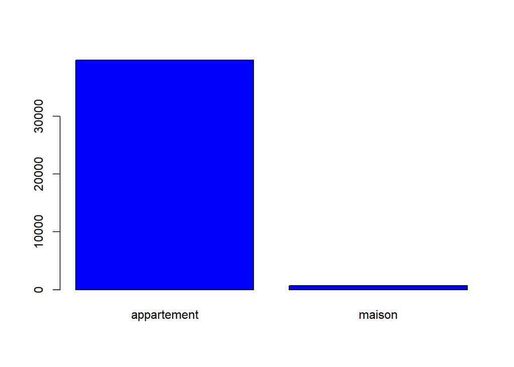

   ```r
   barplot(table(df3$type_property),col="blue")
   ```

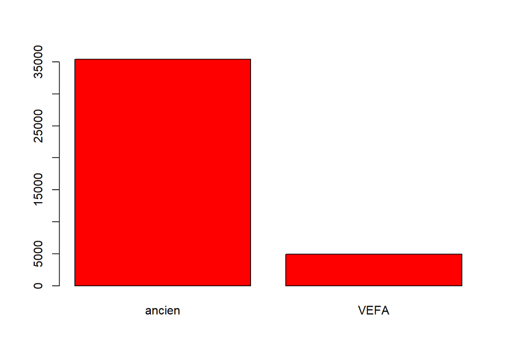

   ```r
   barplot(table(df3$type_purchase),col="red")
   ```

#### Parking count and Number of rooms

2. We will use a histogram for these columns :

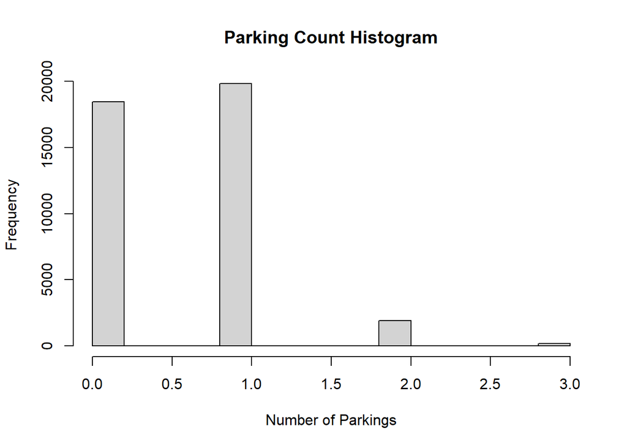

   ```r
   hist(df3$parkings_count, xlab = 'Number of Parkings',  main = 'Parking Count Histogram')
   ```

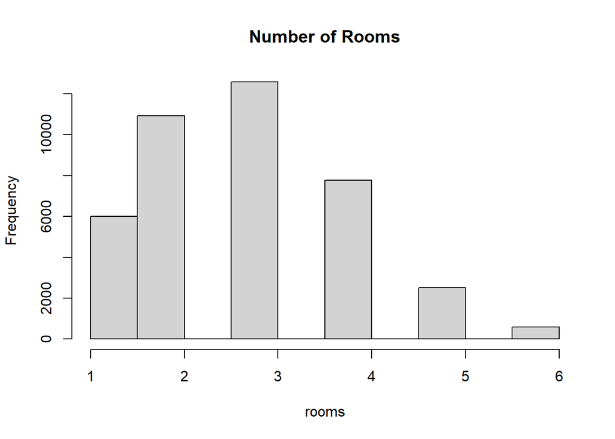

   ```r
   hist(df3$rooms_count, main = 'Number of Rooms', xlab = 'rooms')
   ```

#### Surface housing

3. Histogram for surface area of properties :

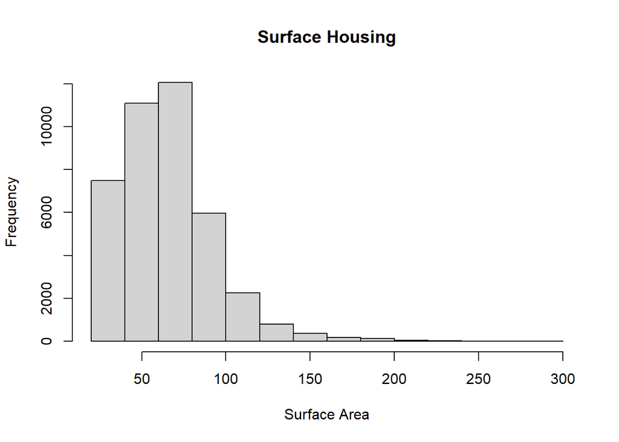

   ```r
   hist(df3$surface_housing, main = 'Surface Housing', xlab = 'Surface Area')
   ```

#### Districts

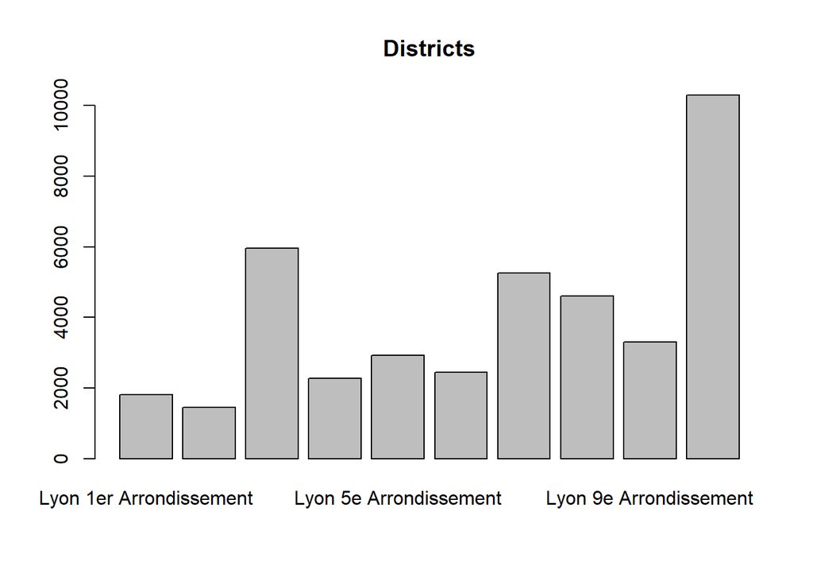

   ```r
   barplot(table(df3$district), main = 'Districts')
   ```

#### Prices per $m^2$

5. Histogram for price per $m^2$ :

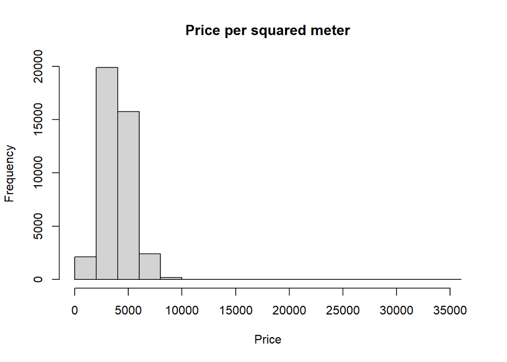

   ```r
   hist(df3$price_per_m2, main = 'Price per squared meter', xlab = 'Price')
   ```

#### Age

6. Histogram for Age of properties :

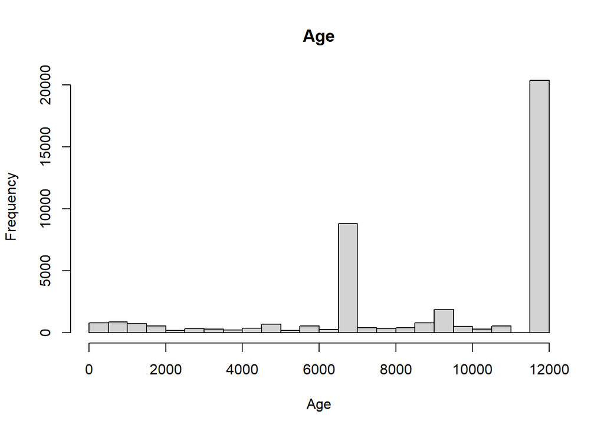

   ```r
   hist(as.numeric(df3$age), main = 'Age', xlab = 'Age')
   ```